# Power Calculations

Sam Walker

10/17/2017

### Purpose

The purpose of this markdown is to perform the basic power calculations needed to determine the number of subjects necessary for the new protocol to have at least 80% power. This protocol is being developed in order to gather more data on age/gender matched controls (HC) to compare to our Sjögren’s Syndrome (SS) data. This markdown uses results from the Najera et al. study and our study.

### Problems Encountered

During this process, there was some confusion on what to use as the effect size for the pwr package function “pwr.t2n.test”. The equation for the effect size for t.tests (Cohen’s D) is |mean1 - mean2|/standard deviation (sd). The confusion came from whether to use the pooled sd or not. According to Cohen, we normally assume that the sd of both groups are equal. However, we know that they are not equal based on the data used in this markdown. Therefore, we should take the pooled sd to give us the closes estimate to the population’s sd. This was confirmed by reading in *Statistical Power Analysis for the Behavioral Sciences* by Jacob Cohen.

### Results

In order to achieve at least 80% power while having the same effect size of the Najera et al. study, we would need to collect data on a minimum of 32 Sjögren’s Syndrome patients and 98 controls. In order to achieve at least 80% power while having the same effect size of our current study, we would need to collect data on a minimum of 16 Sjögren’s Syndrome patients and 20 controls.

The difference in sample sizes seems to come from the difference in effect sizes of the Najera et al. study and our study. Najera effect sizes (CAL:0.58; DMFS:0.65) show a medium difference between the SS and HC groups. Our study effect sizes (CAL:0.97; DMFS:1.03) show a large difference between the SS and HC groups. Since the effect sizes we encountered in our study are larger than the Najera et al. study, it requires a smaller sample size to achieve at least 80% power.

The Najera et al. study and our study may have seen difference effect sizes due to having small sample sizes. In order to more likely achieve 80% power in the new protocol, we will be using the calculated sample sizes based on the Najera et al. study effect sizes. Therefore, we will need to gather data on at least 32 Sjögren’s Syndrome patients and 98 controls.

### Section 1: Najera CAL

This section recreates the code found in http://genomicsclass.github.io/book/pages/power_calculations.html but applies it to the effect size of CAL taken from Najera et al. It then uses the pwr package to create a plot to show 35%, 80%, and 90% power curves. I then identify which samples sizes would be most appropriate based on this plot.

```r
library(pwr)

#create a table to show the info gathered from Najera et al. associated with CAL.
table <- matrix(c(24, 1.96, 0.31, 25, 2.20, 0.48), ncol = 3, byrow = TRUE)
colnames(table) <- c("n", "mean", "sd")
rownames(table) <- c("hc", "ss")
table <- as.table(table)
table
```

```
##        n  mean    sd
## hc 24.00  1.96  0.31
## ss 25.00  2.20  0.48
```

```r
#calculate the power with sample size of 24
N <- 24
alpha <- 0.05
B <- 2000
reject <- function(N, alpha=0.05){
   ss <- sample((rnorm(N, mean = 2.20, sd = 0.48)),N) #This samples from a created normally distributed data set based on the mean and sd SS from the Najera study.
   control <- sample((rnorm(N, mean = 1.96, sd = 0.31)),N) #same as above but with HC group.
   pval <- t.test(ss,control)$p.value
   pval < alpha
}
reject(24)
```

```
## [1] FALSE
```

```r
rejections <- replicate(B,reject(N)) #repeats the above function B (2000) times.
mean(rejections) #returns the power of a sample size of 24
```

```
## [1] 0.4935
```

```r
#create power plot
Ns <- seq(5, 100, 5)
power <- sapply(Ns,function(N){
  rejections <- replicate(B, reject(N))
  mean(rejections)
  })
```

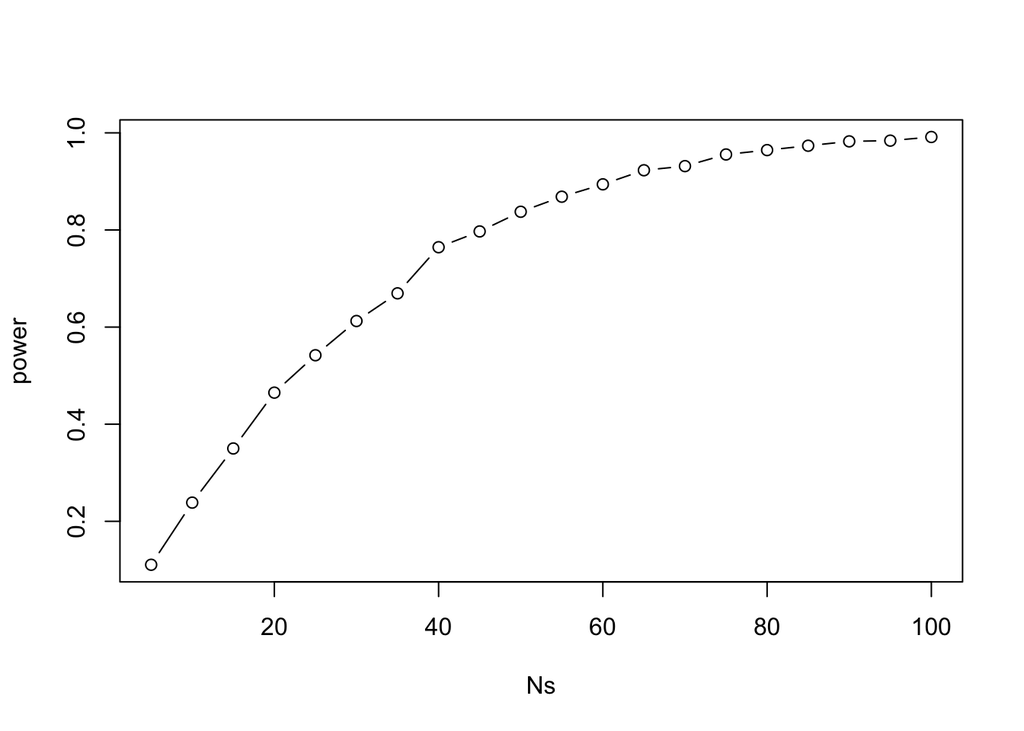

```r
plot(Ns, power, type="b")
```

This plot shows the relationship between sample size and statistical power based on the mean and sd taken from the Najera study CAL data.

```r
library(ggplot2)

#recall the table created earlier in this section
table
```

```
##        n  mean    sd
## hc 24.00  1.96  0.31
## ss 25.00  2.20  0.48
```

```r
#show the difference between the two groups
mu_control <- 1.96
mu_ss <- 2.20
md <- mu_ss - mu_control #mean difference
md
```

```
## [1] 0.24
```

```r
(mu_ss - mu_control)/mu_control * 100 #percent difference
```

```
## [1] 12.2449
```

```r
#calculate Cohen's d (This was checked using a cohen's d calculator online) This value is needed for the pwr package.
psd <- sqrt(((24*.31^2) + (25*.48^2))/(24+25-2)) #pooled sd
cd <- md/psd
cd #shows a medium difference
```

```
## [1] 0.5793224
```

```r
#use pwr package to calculate the power of the Najera study
Najera <- pwr.t2n.test(n1 = 24, n2 = 25, d = cd, sig.level = 0.05, power = NULL)$power
Najera
```

```
## [1] 0.5103071
```

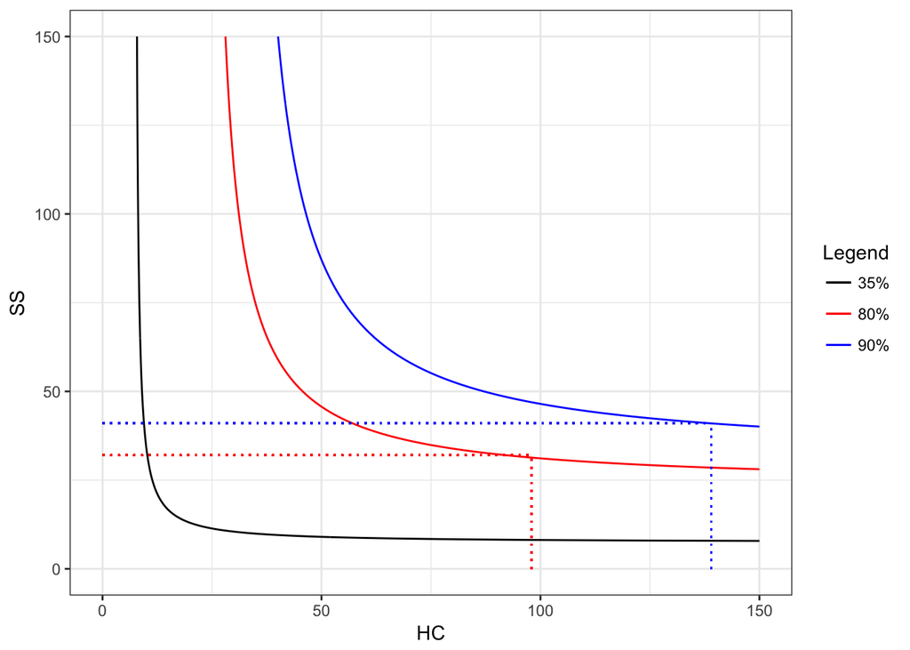

```r
#create a matrix to plot the 35%, 80%, and 90% power curves with ggplot
x <- c(2:150)
y <- c(2:150)
pwr.plot <- expand.grid(x, y) #creates the dataframe of different sample size options
pwr <- function(x){pwr.t2n.test(n1 = x[1], n2 = x[2], d = cd, sig.level = 0.05, power = NULL)$power} #function to be used to add the power to the dataframe
pwr.plot$power <- apply(pwr.plot, 1, pwr) #add the power to the data frame
colnames(pwr.plot) <- c("HC", "SS", "power")
ggplot(pwr.plot, aes(x = HC, y = SS, z = power)) +
    geom_contour(aes(colour = "35%"), breaks = 0.35) +
    geom_contour(aes(colour = "80%"), breaks = 0.80) +
    geom_contour(aes(color = "90%"), breaks = 0.90) +
    geom_segment(aes(x = 0, y = 32, xend = 98, yend = 32), color = "red", linetype = "dotted") +
    geom_segment(aes(x = 98, y = 0, xend = 98, yend = 32), color = "red", linetype = "dotted") +
    geom_segment(aes(x = 0, y = 41, xend = 139, yend = 41), color = "blue", linetype = "dotted") +
    geom_segment(aes(x = 139, y = 0, xend = 139, yend = 41), color = "blue", linetype = "dotted") +
    scale_colour_manual(name="Legend", values = c("35%" = "black", "80%" = "red", "90%" = "blue")) +
    theme_bw()
```

This plot shows the 35%, 80%, and 90% power curves based on the Najera CAL data. The red dotted lines intersect at 32 Sjögren’s Syndrome patients (SS) and 98 Controls (HC). These sample sizes are ideal for achieving 80% power while keeping the number of SS patients needed low. It should be our goal to achieve this minimum number of both groups. The blue dotted lines intersect at 41 SS and 139 HC. These are ideal/reasonable sample sizes to achieve 90% power.

### Section 2: Najera DMFS

This section repeats the previous section’s code except it applies it to the DMFS data taken from Najera et al.

```r
#create a table to show the info gathered from Najera et al. associated with DMFS
table <- matrix(c(24, 52.50, 28.29, 25, 73.60, 34.57), ncol = 3, byrow = TRUE)
colnames(table) <- c("n", "mean", "sd")
rownames(table) <- c("hc", "ss")
table <- as.table(table)
table
```

```
##        n  mean    sd
## hc 24.00 52.50 28.29
## ss 25.00 73.60 34.57
```

```r
#calculate the power with sample size of 24
N <- 24
alpha <- 0.05
B <- 2000
reject <- function(N, alpha=0.05){
   ss <- sample((rnorm(N, mean = 52.50, sd = 28.29)),N) #This samples from a created normally distributed data set based on the mean and sd SS from the Najera study.
   control <- sample((rnorm(N, mean = 73.60, sd = 34.57)),N) #same as above but with HC group.
   pval <- t.test(ss,control)$p.value
   pval < alpha
}
reject(24)
```

```
## [1] TRUE
```

```r
rejections <- replicate(B,reject(N)) #repeats the above function B (2000) times.
mean(rejections) #returns the power of a sample size of 24
```

```
## [1] 0.6195
```

```r
#create power plot
Ns <- seq(5, 100, 5)
power <- sapply(Ns,function(N){
  rejections <- replicate(B, reject(N))
  mean(rejections)
  })
```

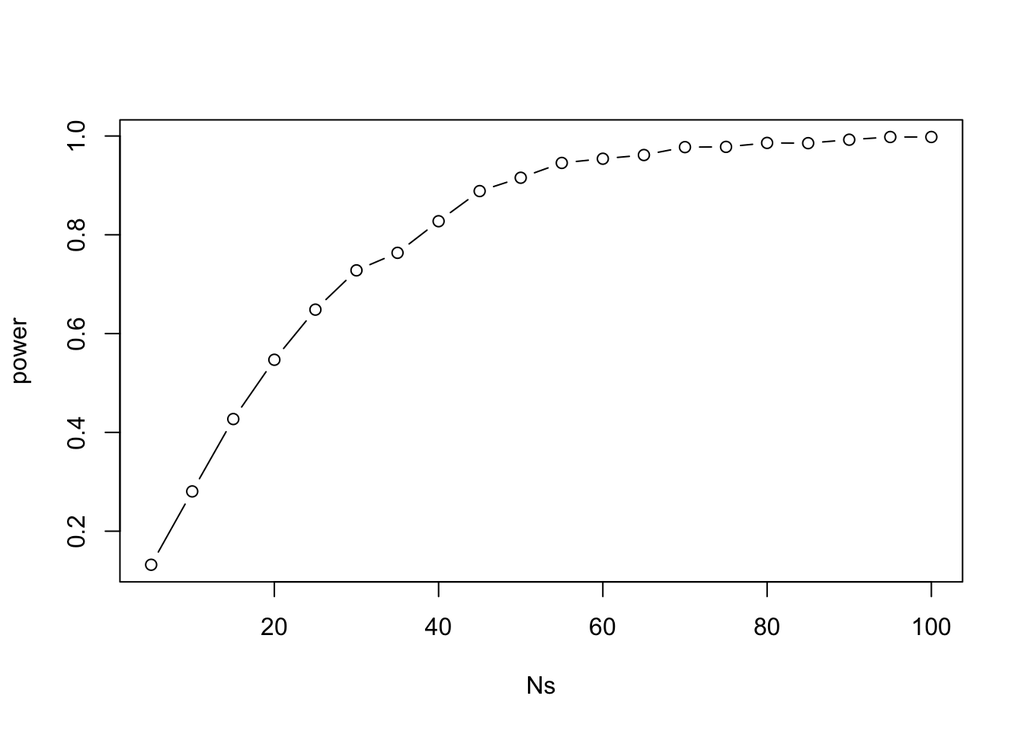

```r
plot(Ns, power, type="b")
```

This plot shows the relationship between sample size and statistical power based on the mean and sd taken from the Najera study DMFS data.

```r
#recall the table created earlier in this section
table
```

```
##        n  mean    sd
## hc 24.00 52.50 28.29
## ss 25.00 73.60 34.57
```

```r
#show the difference between the two groups
mu_control <- 52.50
mu_ss <- 73.60
md <- mu_ss - mu_control #mean difference
md
```

```
## [1] 21.1
```

```r
(mu_ss - mu_control)/mu_control * 100 #percent difference
```

```
## [1] 40.19048
```

```r
#calculate Cohen's d (This was checked using a cohen's d calculator online) This value is needed for the pwr package.
psd <- sqrt(((25*34.57^2) + (24*28.29^2))/(24+25-2)) #pooled sd
cd <- md/psd
cd #shows a medium difference
```

```
## [1] 0.6529162
```

```r
#use pwr package to calculate the power of the Najera study
Najera <- pwr.t2n.test(n1 = 24, n2 = 25, d = cd, sig.level = 0.05, power = NULL)$power
Najera
```

```
## [1] 0.6094727
```

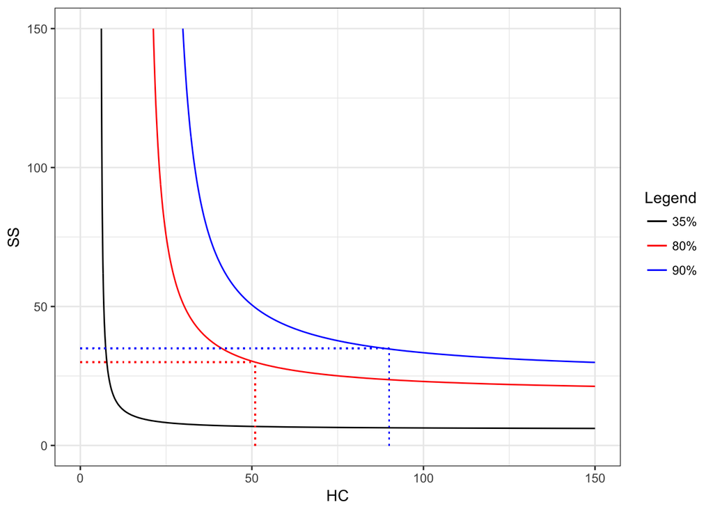

```r
#create a matrix to plot the 35%, 80%, and 90% power curves with ggplot
x <- c(2:150)
y <- c(2:150)
pwr.plot <- expand.grid(x, y) #creates the dataframe of different sample size options
pwr <- function(x){pwr.t2n.test(n1 = x[1], n2 = x[2], d = cd, sig.level = 0.05, power = NULL)$power} #function to be used to add the power to the dataframe
pwr.plot$power <- apply(pwr.plot, 1, pwr) #add the power to the data frame
colnames(pwr.plot) <- c("HC", "SS", "power")
ggplot(pwr.plot, aes(x = HC, y = SS, z = power)) +
    geom_contour(aes(colour = "35%"), breaks = 0.35) +
    geom_contour(aes(colour = "80%"), breaks = 0.80) +
    geom_contour(aes(color = "90%"), breaks = 0.90) +
    geom_segment(aes(x = 0, y = 30, xend = 51, yend = 30), color = "red", linetype = "dotted") +
    geom_segment(aes(x = 51, y = 0, xend = 51, yend = 30), color = "red", linetype = "dotted") +
    geom_segment(aes(x = 0, y = 35, xend = 90, yend = 35), color = "blue", linetype = "dotted") +
    geom_segment(aes(x = 90, y = 0, xend = 90, yend = 35), color = "blue", linetype = "dotted") +
    scale_colour_manual(name="Legend", values = c("35%" = "black", "80%" = "red", "90%" = "blue")) +
    theme_bw()
```

This plot shows the 35%, 80%, and 90% power curves based on the Najera DMFS data. The red dotted lines intersect at 30 Sjögren’s Syndrome patients (SS) and 51 Controls (HC). These sample sizes are ideal for achieving 80% power while keeping the number of SS patients needed low. It should be our goal to achieve this minimum number of both groups. The blue dotted lines intersect at 35 SS and 90 HC. These are ideal/reasonable sample sizes to achieve 90% power.

### Section 3: Gathering our data

This section is used to gather our data to be used in the following sections. The code can be found in the rmarkdown file.

### Section 4: Our Study CAL

This section was used to recreate the code found in http://genomicsclass.github.io/book/pages/power_calculations.html but applies it to the effect size of CAL taken from our study. It then uses the pwr package to create a plot to show 35%, 80%, and 90% power curves. I then identify which samples sizes would be most appropriate based on this plot.

```r
library(pwr)

#create a table to show the info gathered from our study associated with CAL
table <- matrix(c(23, 1.31, 0.93, 32, 2.25, 0.96), ncol = 3, byrow = TRUE)
colnames(table) <- c("n", "mean", "sd")
rownames(table) <- c("hc", "ss")
table <- as.table(table)
table
```

```
##        n  mean    sd
## hc 23.00  1.31  0.93
## ss 32.00  2.25  0.96
```

```r
#calculate the power with sample size of 24
N <- 24
alpha <- 0.05
B <- 2000
reject <- function(N, alpha=0.05){
   ss <- sample((rnorm(N, mean = 2.25, sd = 0.96)),N) #This samples from a created normal distributed data set based on the mean and sd SS from our study.
   control <- sample((rnorm(N, mean = 1.31, sd = 0.93)),N) #same as above but with HC group.
   pval <- t.test(ss,control)$p.value
   pval < alpha
}
reject(24)
```

```
## [1] TRUE
```

```r
rejections <- replicate(B,reject(N)) #repeats the above function B (2000) times.
mean(rejections) #returns the power of a sample size of 24
```

```
## [1] 0.9125
```

```r
#create power plot
Ns <- seq(5, 100, 5)
power <- sapply(Ns,function(N){
  rejections <- replicate(B, reject(N))
  mean(rejections)
  })
```

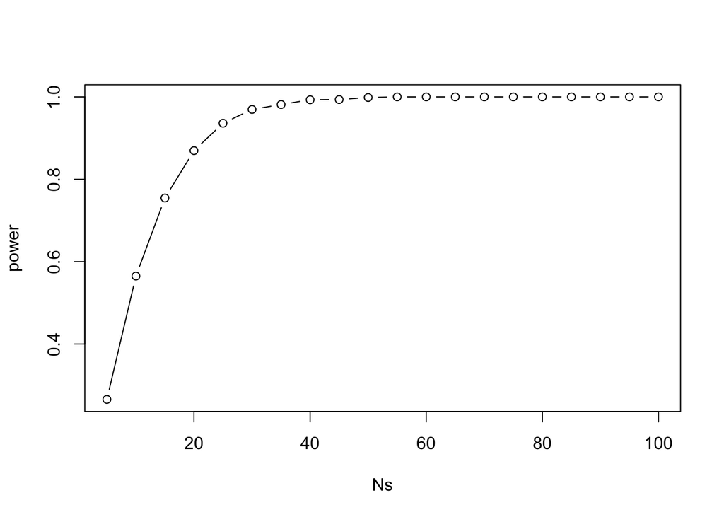

```r
plot(Ns, power, type="b")
```

This plot shows the relationship between sample size and statistical power based on the mean and sd taken from the our study’s CAL data.

```r
#recall the table created earlier in this section
table
```

```
##        n  mean    sd
## hc 23.00  1.31  0.93
## ss 32.00  2.25  0.96
```

```r
#show the difference between the two groups
mu_control <- mean(hc.perio$mean.cal) #mean CAL of control group
mu_control
```

```
## [1] 1.313314
```

```r
mu_ss <- mean(ss.perio$mean.cal) #mean CAL of SS group
mu_ss
```

```
## [1] 2.251095
```

```r
md <- mu_ss - mu_control #mean difference
md
```

```
## [1] 0.9377808
```

```r
(mu_ss - mu_control)/mu_control * 100 #percent difference
```

```
## [1] 71.40569
```

```r
#calculate Cohen's d (This was checked using a cohen's d calculator online) This value is needed for the pwr package.
ss.sd <- sd(ss.perio$mean.cal) #sd of ss group
ss.sd
```

```
## [1] 0.9571655
```

```r
hc.sd <- sd(hc.perio$mean.cal) #sd of control group
hc.sd
```

```
## [1] 0.9349482
```

```r
psd <- sqrt(((32*ss.sd^2) + (23*hc.sd^2))/(32+23-2)) #pooled sd
cd <- md/psd
cd #shows a large difference
```

```
## [1] 0.9711314
```

```r
#use pwr package to calculate the power of our study
Ours <- pwr.t2n.test(n1 = 23, n2 = 32, d = cd, sig.level = 0.05, power = NULL)$power
Ours
```

```
## [1] 0.9366778
```

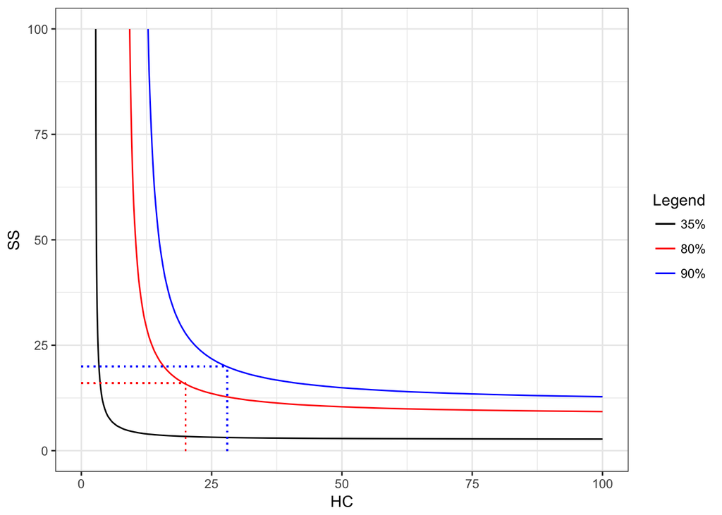

```r
#plot the power based on differing n values of both groups
x <- c(2:100)
y <- c(2:100)
pwr.plot <- expand.grid(x, y) #creates the dataframe of different sample size options
pwr <- function(x){pwr.t2n.test(n1 = x[1], n2 = x[2], d = cd, sig.level = 0.05, power = NULL)$power} #function to be used to add the power to the dataframe
pwr.plot$power <- apply(pwr.plot, 1, pwr) #add the power to the data frame
colnames(pwr.plot) <- c("HC", "SS", "power")
ggplot(pwr.plot, aes(x = HC, y = SS, z = power)) +
    geom_contour(aes(colour = "35%"), breaks = 0.35) +
    geom_contour(aes(colour = "80%"), breaks = 0.80) +
    geom_contour(aes(color = "90%"), breaks = 0.90) +
    geom_segment(aes(x = 0, y = 16, xend = 20, yend = 16), color = "red", linetype = "dotted") +
    geom_segment(aes(x = 20, y = 0, xend = 20, yend = 16), color = "red", linetype = "dotted") +
    geom_segment(aes(x = 0, y = 20, xend = 28, yend = 20), color = "blue", linetype = "dotted") +
    geom_segment(aes(x = 28, y = 0, xend = 28, yend = 20), color = "blue", linetype = "dotted") +
    scale_colour_manual(name="Legend", values = c("35%" = "black", "80%" = "red", "90%" = "blue")) +
    theme_bw()
```

This plot shows the 35%, 80%, and 90% power curves based on our study’s CAL data. The red dotted lines intersect at 16 Sjögren’s Syndrome patients (SS) and 20 Controls (HC). These sample sizes are ideal for achieving 80% power while keeping both the number of SS patients and controls low. It should be our goal to achieve this minimum sample size of both groups. The blue dotted lines intersect at 20 SS and 28 HC. These are ideal/reasonable sample sizes to achieve 90% power and are very close to the numbers needed to reach 80% power. Therefore, it would most likely be easy to reach 90% power.

### Section 5: Our Study DMFS

This section repeats the previous section’s code except it applies it to the DMFS data taken from our study.

```r
#create a table to show the info gathered from our study associated with DMFS
table <- matrix(c(23, 41.5, 17.69, 32, 68.9, 30.54), ncol = 3, byrow = TRUE)
colnames(table) <- c("n", "mean", "sd")
rownames(table) <- c("hc", "ss")
table <- as.table(table)
table
```

```
##        n  mean    sd
## hc 23.00 41.50 17.69
## ss 32.00 68.90 30.54
```

```r
#calculate the power with sample size of 24
N <- 24
alpha <- 0.05
B <- 2000
reject <- function(N, alpha=0.05){
   ss <- sample((rnorm(N, mean = 68.9, sd = 30.54)),N) #This samples from a created normal distributed data set based on the mean and sd SS from our study.
   control <- sample((rnorm(N, mean = 41.5, sd = 17.69)),N) #same as above but with HC group.
   pval <- t.test(ss,control)$p.value
   pval < alpha
}
reject(24)
```

```
## [1] TRUE
```

```r
rejections <- replicate(B,reject(N)) #repeats the above function B (2000) times.
mean(rejections) #returns the power of a sample size of 24
```

```
## [1] 0.9665
```

```r
#create power plot
Ns <- seq(5, 100, 5)
power <- sapply(Ns,function(N){
  rejections <- replicate(B, reject(N))
  mean(rejections)
  })
```

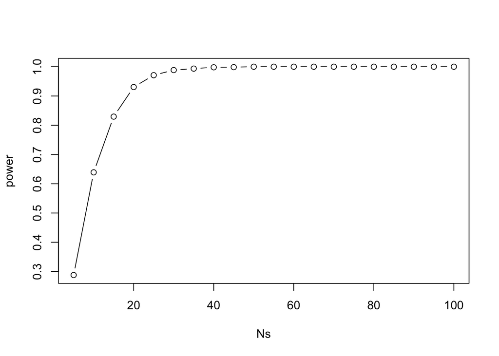

```r
plot(Ns, power, type="b")
```

This plot shows the relationship between sample size and statistical power based on the mean and sd taken from our study’s DMFS data.

```r
#recall the table created earlier in this section
table
```

```
##        n  mean    sd
## hc 23.00 41.50 17.69
## ss 32.00 68.90 30.54
```

```r
#show the difference between the two groups
mu_control <- mean(hc.caries$DMFS.bysubject)
mu_control
```

```
## [1] 41.52174
```

```r
mu_ss <- mean(ss.caries$DMFS.bysubject)
mu_ss
```

```
## [1] 68.875
```

```r
md <- mu_ss - mu_control #mean difference
md
```

```
## [1] 27.35326
```

```r
(mu_ss - mu_control)/mu_control * 100 #percent difference
```

```
## [1] 65.87696
```

```r
#calculate Cohen's d (This was checked using a cohen's d calculator online) This value is needed for the pwr package.
ss.sd <- sd(ss.caries$DMFS.bysubject)
ss.sd
```

```
## [1] 30.53898
```

```r
hc.sd <- sd(hc.caries$DMFS.bysubject)
hc.sd
```

```
## [1] 17.69147
```

```r
psd <- sqrt(((32*ss.sd^2) + (23*hc.sd^2))/(32+23-2)) #pooled sd
cd <- md/psd
cd #shows a large difference
```

```
## [1] 1.034653
```

```r
#use pwr package to calculate the power of the our study
Ours <- pwr.t2n.test(n1 = 23, n2 = 33, d = cd, sig.level = 0.05, power = NULL)$power
Ours
```

```
## [1] 0.9625072
```

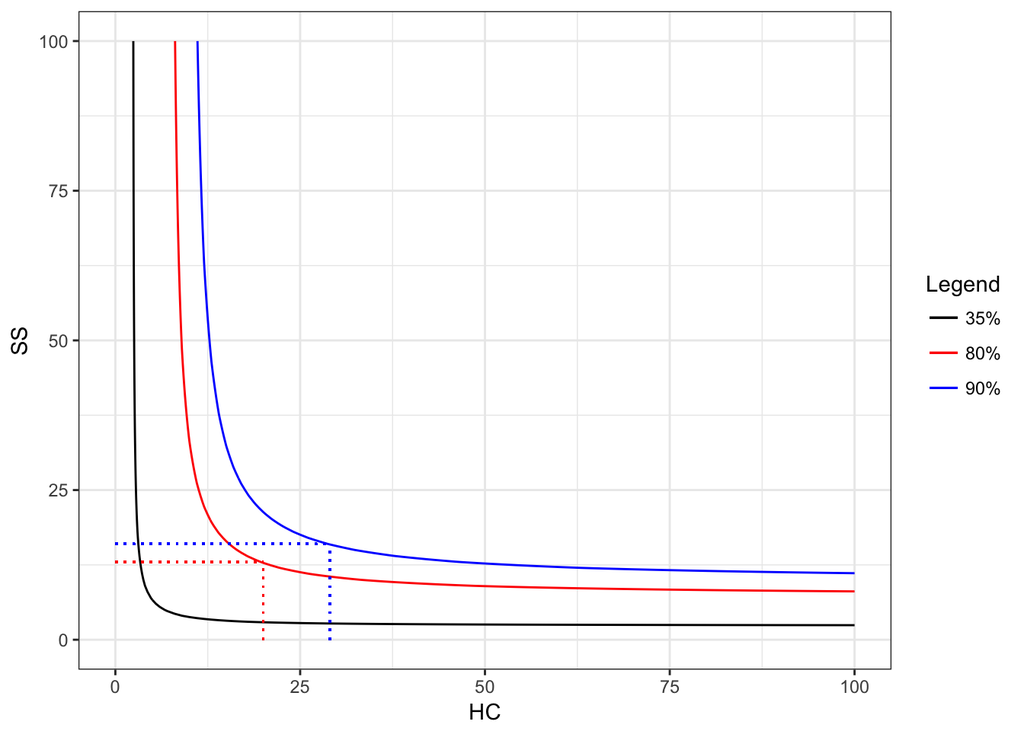

```r
#plot the power based on differing n values of both groups
x <- c(2:100)
y <- c(2:100)
pwr.plot <- expand.grid(x, y) #creates the dataframe of different sample size options
pwr <- function(x){pwr.t2n.test(n1 = x[1], n2 = x[2], d = cd, sig.level = 0.05, power = NULL)$power} #function to be used to add the power to the dataframe
pwr.plot$power <- apply(pwr.plot, 1, pwr) #add the power to the data frame
colnames(pwr.plot) <- c("HC", "SS", "power")
ggplot(pwr.plot, aes(x = HC, y = SS, z = power)) +
  geom_contour(aes(colour = "35%"), breaks = 0.35) +
  geom_contour(aes(colour = "80%"), breaks = 0.80) +
  geom_contour(aes(color = "90%"), breaks = 0.90) +
  geom_segment(aes(x = 0, y = 13, xend = 20, yend = 13), color = "red", linetype = "dotted") +
  geom_segment(aes(x = 20, y = 0, xend = 20, yend = 13), color = "red", linetype = "dotted") +
  geom_segment(aes(x = 0, y = 16, xend = 29, yend = 16), color = "blue", linetype = "dotted") +
  geom_segment(aes(x = 29, y = 0, xend = 29, yend = 16), color = "blue", linetype = "dotted") +
  scale_colour_manual(name="Legend", values = c("35%" = "black", "80%" = "red", "90%" = "blue")) +
  theme_bw()
```

This plot shows the 35%, 80%, and 90% power curves based on our study’s DMFS data. The red dotted lines intersect at 13 Sjögren’s Syndrome patients (SS) and 20 Controls (HC). These sample sizes are ideal for achieving 80% power while keeping both the number of SS patients and controls low. It should be our goal to achieve this minimum sample size of both groups. The blue dotted lines intersect at 16 SS and 29 HC. These are ideal/reasonable sample sizes to achieve 90% power and are very close to the numbers needed to reach 80% power. Therefore, it would most likely be easy to reach 90% power.